# Summer Internship

Navin Ramanan

6/01/2022

##Setup

1. Map Ensembl ID to Gene Symbol in the counts file
2. Write Counts Data with Gene Symbol to CSV
3. Reading and filtering Hippocampus count and metadata files
4. Reading and filtering Cortex count and metadata files
5. Cortex: APP=APP, Age=12, Diet=Control vs Supplemented (~APP + Age + Diet) APP12Control vs APP12Supplemented

```
## Cortex: Running DESeq2 for Diet(Control vs Supplemented) with APP=APP, Age=12:padj < 0.05 and 0.10
```

```
## Cortex: APP12Control vs APP12Supplemented
```

```
## resultsNames:
```

```
##  [1] "Intercept"
##  [2] "group_APP12Supplemented_vs_APP12Control"
##  [3] "group_APP3Control_vs_APP12Control"
##  [4] "group_APP3Supplemented_vs_APP12Control"
##  [5] "group_APP6Control_vs_APP12Control"
##  [6] "group_APP6Supplemented_vs_APP12Control"
##  [7] "group_APP9Control_vs_APP12Control"
##  [8] "group_APP9Supplemented_vs_APP12Control"
##  [9] "group_WT12Control_vs_APP12Control"
## [10] "group_WT12Supplemented_vs_APP12Control"
## [11] "group_WT3Control_vs_APP12Control"
## [12] "group_WT3Supplemented_vs_APP12Control"
## [13] "group_WT6Control_vs_APP12Control"
## [14] "group_WT6Supplemented_vs_APP12Control"
## [15] "group_WT9Control_vs_APP12Control"
## [16] "group_WT9Supplemented_vs_APP12Control"
## [1] "group"             "APP12Control"      "APP12Supplemented"
##
## out of 34880 with nonzero total read count
## adjusted p-value < 0.1
## LFC > 0 (up)       : 2, 0.0057%
## LFC < 0 (down)     : 0, 0%
## outliers [1]       : 101, 0.29%
## low counts [2]     : 0, 0%
## (mean count < 0)
## [1] see 'cooksCutoff' argument of ?results
## [2] see 'independentFiltering' argument of ?results
```

```
## log2 fold change (MLE): group APP12Control vs APP12Supplemented
## Wald test p-value: group APP12Control vs APP12Supplemented
## DataFrame with 10 rows and 6 columns
##                     baseMean log2FoldChange     lfcSE       stat      pvalue
##                    <numeric>      <numeric> <numeric>  <numeric>   <numeric>
## ENSMUSG00000075014  6.926789     18.8623803  3.162891  5.9636509 2.46663e-09
## ENSMUSG00000048620  2.421723     17.8907223  3.878978  4.6122261 3.98379e-06
## ENSMUSG00000102628 17.922102      0.3381056  0.469527  0.7200981 4.71465e-01
## ENSMUSG00000097426  0.160601      0.0000000  8.243028  0.0000000 1.00000e+00
## ENSMUSG00000086053  1.154142     -0.0505798  1.519113 -0.0332956 9.73439e-01
## ENSMUSG00000102135  0.631465      0.5703828  2.047636  0.2785567 7.80585e-01
## ENSMUSG00000100764  6.120378     -0.4374207  0.555684 -0.7871757 4.31179e-01
## ENSMUSG00000102095  0.498763      1.4941801  2.317832  0.6446455 5.19157e-01
## ENSMUSG00000100635  5.830331      0.1048746  0.616877  0.1700090 8.65003e-01
## ENSMUSG00000100480 35.748764      0.2425910  0.284931  0.8514031 3.94545e-01
##                           padj
##                      <numeric>
## ENSMUSG00000075014 8.57871e-05
## ENSMUSG00000048620 6.92762e-02
## ENSMUSG00000102628 1.00000e+00
## ENSMUSG00000097426 1.00000e+00
## ENSMUSG00000086053 1.00000e+00
## ENSMUSG00000102135 1.00000e+00
## ENSMUSG00000100764 1.00000e+00
## ENSMUSG00000102095 1.00000e+00
## ENSMUSG00000100635 1.00000e+00
## ENSMUSG00000100480 1.00000e+00
```

```
## log2 fold change (MLE): group APP12Control vs APP12Supplemented
## Wald test p-value: group APP12Control vs APP12Supplemented
## DataFrame with 34880 rows and 6 columns
##                       baseMean log2FoldChange     lfcSE       stat      pvalue
##                      <numeric>      <numeric> <numeric>  <numeric>   <numeric>
## ENSMUSG00000075014    6.926789     18.8623803  3.162891  5.9636509 2.46663e-09
## ENSMUSG00000048620    2.421723     17.8907223  3.878978  4.6122261 3.98379e-06
## ENSMUSG00000102628   17.922102      0.3381056  0.469527  0.7200981 4.71465e-01
## ENSMUSG00000097426    0.160601      0.0000000  8.243028  0.0000000 1.00000e+00
## ENSMUSG00000086053    1.154142     -0.0505798  1.519113 -0.0332956 9.73439e-01
## ...                        ...            ...       ...        ...         ...
## ENSMUSG00000109212    0.769426       0.000000  8.243028  0.0000000          NA
## ENSMUSG00000054134   40.269651       0.053669  0.755769  0.0710124          NA
## ENSMUSG00000024028    0.789155       0.000000  8.243028  0.0000000          NA
## ENSMUSG00000061808 1664.189531      -0.442513  0.828358 -0.5342048          NA
## ENSMUSG00000037451    1.547250     -15.099759  8.243028 -1.8318220          NA
##                           padj
##                      <numeric>
## ENSMUSG00000075014 8.57871e-05
## ENSMUSG00000048620 6.92762e-02
## ENSMUSG00000102628 1.00000e+00
## ENSMUSG00000097426 1.00000e+00
## ENSMUSG00000086053 1.00000e+00
## ...                        ...
## ENSMUSG00000109212          NA
## ENSMUSG00000054134          NA
## ENSMUSG00000024028          NA
## ENSMUSG00000061808          NA
## ENSMUSG00000037451          NA
```

```
## class: DESeqDataSet
## dim: 34880 96
## metadata(1): version
## assays(4): counts mu H cooks
## rownames(34880): ENSMUSG00000102628 ENSMUSG00000097426 ...
##   ENSMUSG00000095041 ENSMUSG00000095742
## rowData names(78): baseMean baseVar ... deviance maxCooks
## colnames(96): 102 103 ... 95 96
## colData names(6): Sex Diet ... group sizeFactor
```

```
## Cortex DESeq2 result is saved in file: 'Cortex_deseq_results_Diet_APP_12.csv'
```

```
## Cortex DESeq2 normalized counts is saved in file: 'Cortex_deseq_norm_counts_Diet_APP_12.csv'
```

```
## Cortex DESeq2 result with Gene names (mgi_symbols) is saved in file: 'Cortex_deseq_results_with_genename_Diet_APP_12.csv'
```

```
## [1] 34880
```

```
## [1] 1
```

```
## Cortex DESeq2 result after padj (0.05) filtering is saved in file: 'Cortex_deseq_results_Diet_APP_12_padj_05_filtered.csv'
```

```
## Number of DE genes significant at padj < 0.05 for Cortex:APP12Control vs APP12Supplemented: 1
```

```
## Number of DE genes discarded after padj threshold 0.05 filtering for Cortex:APP12Control vs APP12Supplemented: 34879
```

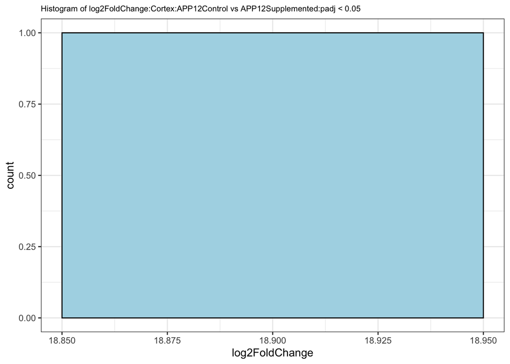

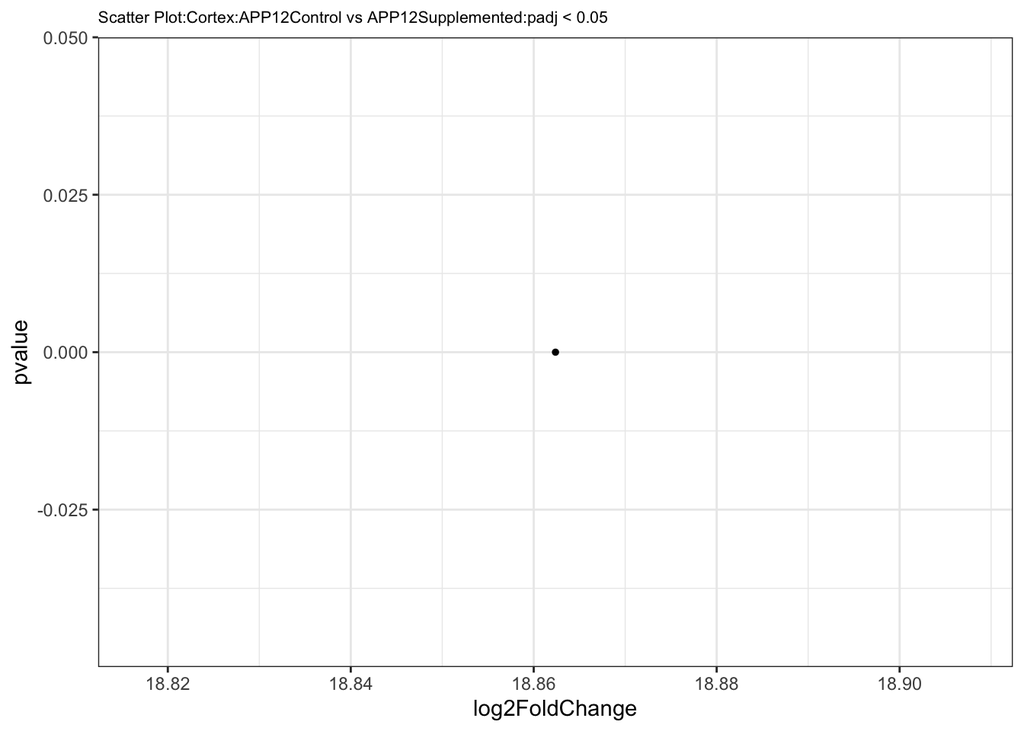

```
## [1] 34880
```

```
## [1] 2
```

```
## Cortex DESeq2 result after padj (0.1) filtering is saved in file: 'Cortex_deseq_results_Diet_APP_12_padj_1_filtered.csv'
```

```
## Number of DE genes significant at padj < 0.1 for Cortex:APP12Control vs APP12Supplemented: 2
```

```
## Number of DE genes discarded after padj threshold 0.1 filtering for Cortex:APP12Control vs APP12Supplemented: 34878
```

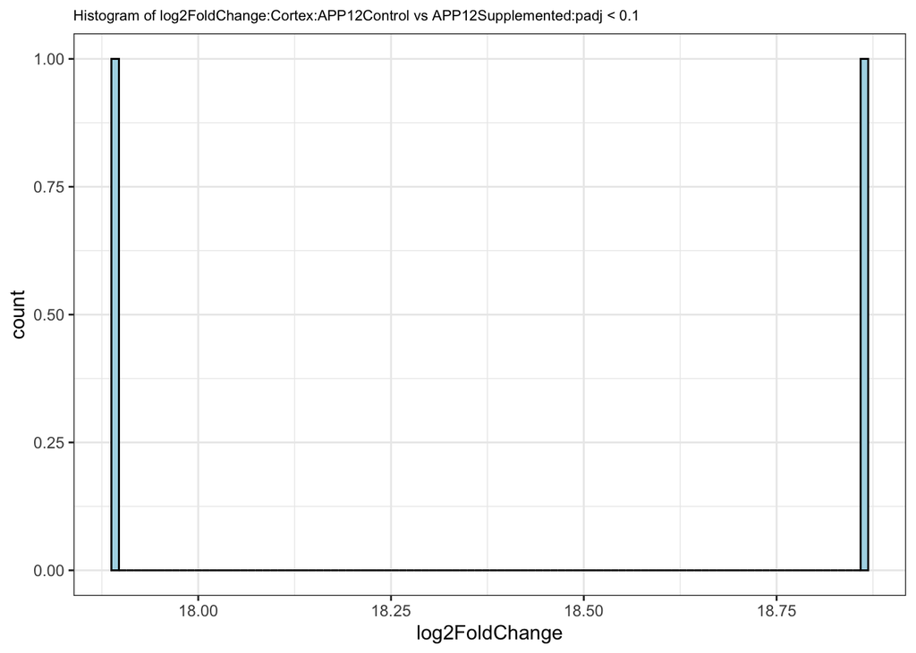

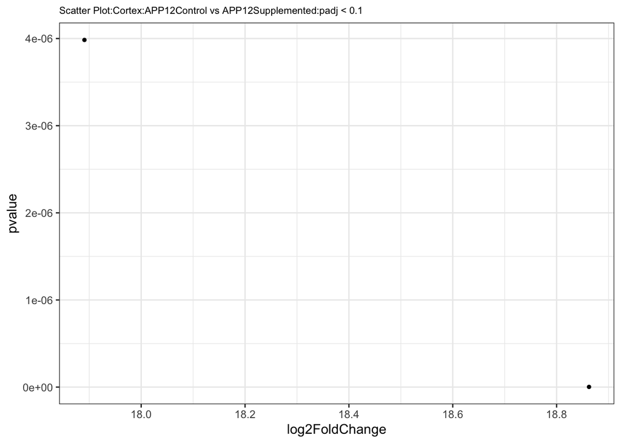

6. Cortex: Enhanced Volcano Plot

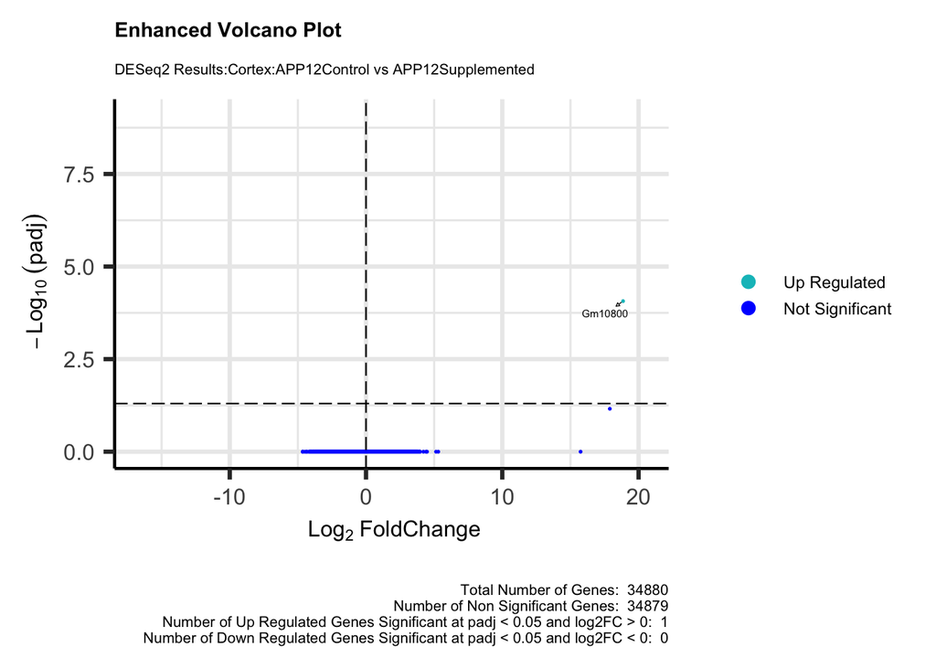

7. Cortex: Heatmap

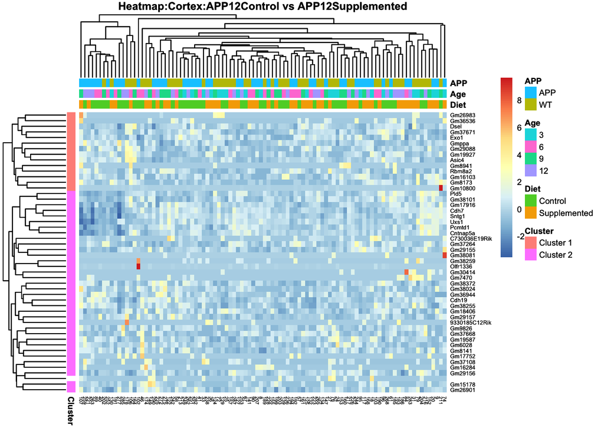

8. Hippocampus: APP=APP, Age=12, Diet=Control vs Supplemented (~APP + Age + Diet) APP12Control vs APP12Supplemented

```
## Hippocampus: Running DESeq2 for Diet(Control vs Supplemented) with APP=APP, Age=12:padj < 0.05 and 0.10
```

```
## Hippocampus: APP12Control vs APP12Supplemented
```

```
## resultsNames:
```

```
##  [1] "Intercept"
##  [2] "group_APP12Supplemented_vs_APP12Control"
##  [3] "group_APP3Control_vs_APP12Control"
##  [4] "group_APP3Supplemented_vs_APP12Control"
##  [5] "group_APP6Control_vs_APP12Control"
##  [6] "group_APP6Supplemented_vs_APP12Control"
##  [7] "group_APP9Control_vs_APP12Control"
##  [8] "group_APP9Supplemented_vs_APP12Control"
##  [9] "group_WT12Control_vs_APP12Control"
## [10] "group_WT12Supplemented_vs_APP12Control"
## [11] "group_WT3Control_vs_APP12Control"
## [12] "group_WT3Supplemented_vs_APP12Control"
## [13] "group_WT6Control_vs_APP12Control"
## [14] "group_WT6Supplemented_vs_APP12Control"
## [15] "group_WT9Control_vs_APP12Control"
## [16] "group_WT9Supplemented_vs_APP12Control"
## [1] "group"             "APP12Control"      "APP12Supplemented"
##
## out of 33271 with nonzero total read count
## adjusted p-value < 0.1
## LFC > 0 (up)       : 3, 0.009%
## LFC < 0 (down)     : 1, 0.003%
## outliers [1]       : 77, 0.23%
## low counts [2]     : 0, 0%
## (mean count < 0)
## [1] see 'cooksCutoff' argument of ?results
## [2] see 'independentFiltering' argument of ?results
```

```
## log2 fold change (MLE): group APP12Control vs APP12Supplemented
## Wald test p-value: group APP12Control vs APP12Supplemented
## DataFrame with 10 rows and 6 columns
##                     baseMean log2FoldChange     lfcSE      stat      pvalue
##                    <numeric>      <numeric> <numeric> <numeric>   <numeric>
## ENSMUSG00000074768   7.26910       19.82298  3.359608   5.90038 3.62656e-09
## ENSMUSG00000086756   5.46602       16.06128  3.505441   4.58182 4.60956e-06
## ENSMUSG00000078640  75.01498       -1.20967  0.266077  -4.54634 5.45873e-06
## ENSMUSG00000036961  14.00146        3.33752  0.729310   4.57626 4.73357e-06
## ENSMUSG00000047606 221.24595       -1.55257  0.365374  -4.24927 2.14465e-05
## ENSMUSG00000054320  37.37044        1.89724  0.451375   4.20325 2.63115e-05
## ENSMUSG00000035860 153.04964        1.61944  0.397329   4.07580 4.58559e-05
## ENSMUSG00000087064  28.81898        1.96836  0.489391   4.02207 5.76901e-05
## ENSMUSG00000042096   4.96564        2.98267  0.756847   3.94092 8.11702e-05
## ENSMUSG00000039099  23.35292        1.76910  0.446372   3.96328 7.39265e-05
##                          padj
##                     <numeric>
## ENSMUSG00000074768 0.00012038
## ENSMUSG00000086756 0.04529928
## ENSMUSG00000078640 0.04529928
## ENSMUSG00000036961 0.04529928
## ENSMUSG00000047606 0.14237880
## ENSMUSG00000054320 0.14556408
## ENSMUSG00000035860 0.21744882
## ENSMUSG00000087064 0.23937060
## ENSMUSG00000042096 0.24685597
## ENSMUSG00000039099 0.24685597
```

```
## log2 fold change (MLE): group APP12Control vs APP12Supplemented
## Wald test p-value: group APP12Control vs APP12Supplemented
## DataFrame with 33271 rows and 6 columns
##                       baseMean log2FoldChange     lfcSE      stat      pvalue
##                      <numeric>      <numeric> <numeric> <numeric>   <numeric>
## ENSMUSG00000074768     7.26910       19.82298  3.359608   5.90038 3.62656e-09
## ENSMUSG00000086756     5.46602       16.06128  3.505441   4.58182 4.60956e-06
## ENSMUSG00000078640    75.01498       -1.20967  0.266077  -4.54634 5.45873e-06
## ENSMUSG00000036961    14.00146        3.33752  0.729310   4.57626 4.73357e-06
## ENSMUSG00000047606   221.24595       -1.55257  0.365374  -4.24927 2.14465e-05
## ...                        ...            ...       ...       ...         ...
## ENSMUSG00000068196   434.29152       0.808602   1.19930 0.6742264          NA
## ENSMUSG00000053375     1.58633       0.195684   3.32173 0.0589103          NA
## ENSMUSG00000023122    38.89638       0.368338   2.52343 0.1459672          NA
## ENSMUSG00000023943    18.46229       1.956490   2.66620 0.7338108          NA
## ENSMUSG00000061808 34756.71162       2.382334   1.53479 1.5522195          NA
##                          padj
##                     <numeric>
## ENSMUSG00000074768 0.00012038
## ENSMUSG00000086756 0.04529928
## ENSMUSG00000078640 0.04529928
## ENSMUSG00000036961 0.04529928
## ENSMUSG00000047606 0.14237880
## ...                       ...
## ENSMUSG00000068196         NA
## ENSMUSG00000053375         NA
## ENSMUSG00000023122         NA
## ENSMUSG00000023943         NA
## ENSMUSG00000061808         NA
```

```
## class: DESeqDataSet
## dim: 33271 96
## metadata(1): version
## assays(4): counts mu H cooks
## rownames(33271): ENSMUSG00000102628 ENSMUSG00000086053 ...
##   ENSMUSG00000095041 ENSMUSG00000095742
## rowData names(78): baseMean baseVar ... deviance maxCooks
## colnames(96): 102 103 ... 95 96
## colData names(6): Sex Diet ... group sizeFactor
```

```
## Hippocampus DESeq2 result is saved in file: 'Hippocampus_deseq_results_Diet_APP_12.csv'
```

```
## Hippocampus DESeq2 normalized counts is saved in file: 'Hippocampus_deseq_norm_counts_Diet_APP_12.csv'
```

```
## Hippocampus DESeq2 result with Gene names (mgi_symbols) is saved in file: 'Hippocampus_deseq_results_with_genename_Diet_APP_12.csv'
```

```
## Hippocampus DESeq2 result after padj (0.05) filtering is saved in file: 'Hippocampus_deseq_results_Diet_APP_12_padj_05_filtered.csv'
```

```
## Number of DE genes significant at padj < 0.05 for Hippocampus:APP12Control vs APP12Supplemented: 4
```

```
## Number of DE genes discarded after padj threshold < 0.05 filtering for Hippocampus:APP12Control vs APP12Supplemented: 33267
```

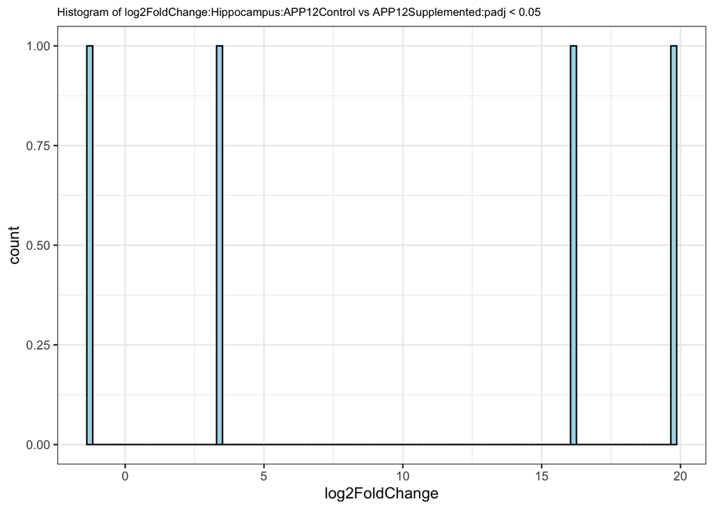

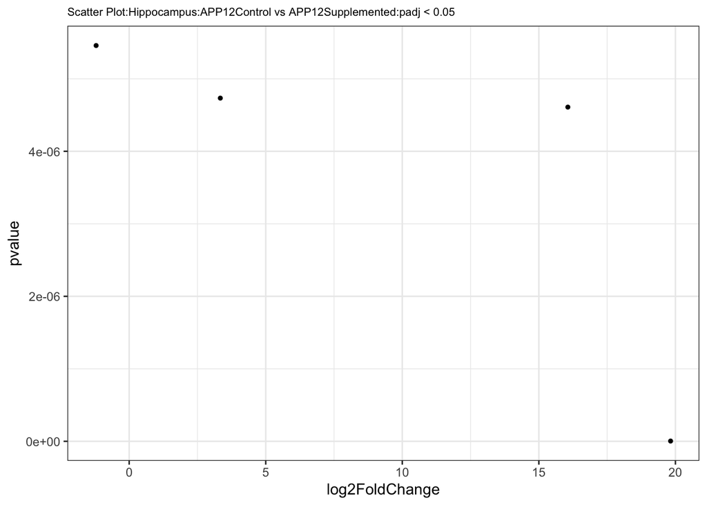

```
## Hippocampus DESeq2 result after padj (0.1) filtering is saved in file: 'Hippocampus_deseq_results_Diet_APP_12_padj_1_filtered.csv'
```

```
## Number of DE genes significant at padj < 0.1 for Hippocampus:APP12Control vs APP12Supplemented: 4
```

```
## Number of DE genes discarded after padj threshold < 0.1 filtering for Hippocampus:APP12Control vs APP12Supplemented: 33267
```

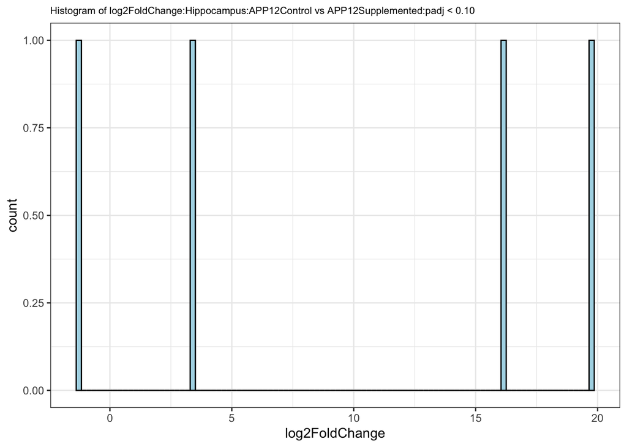

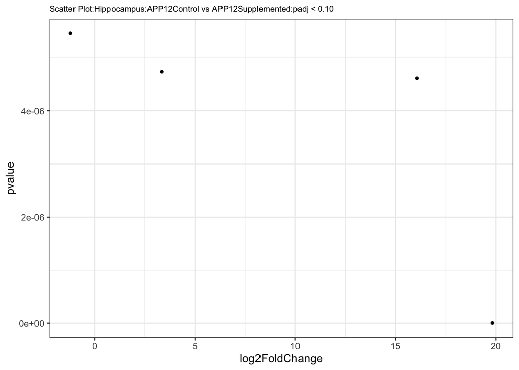

9. Hippocampus: Enhanced Volcano Plot

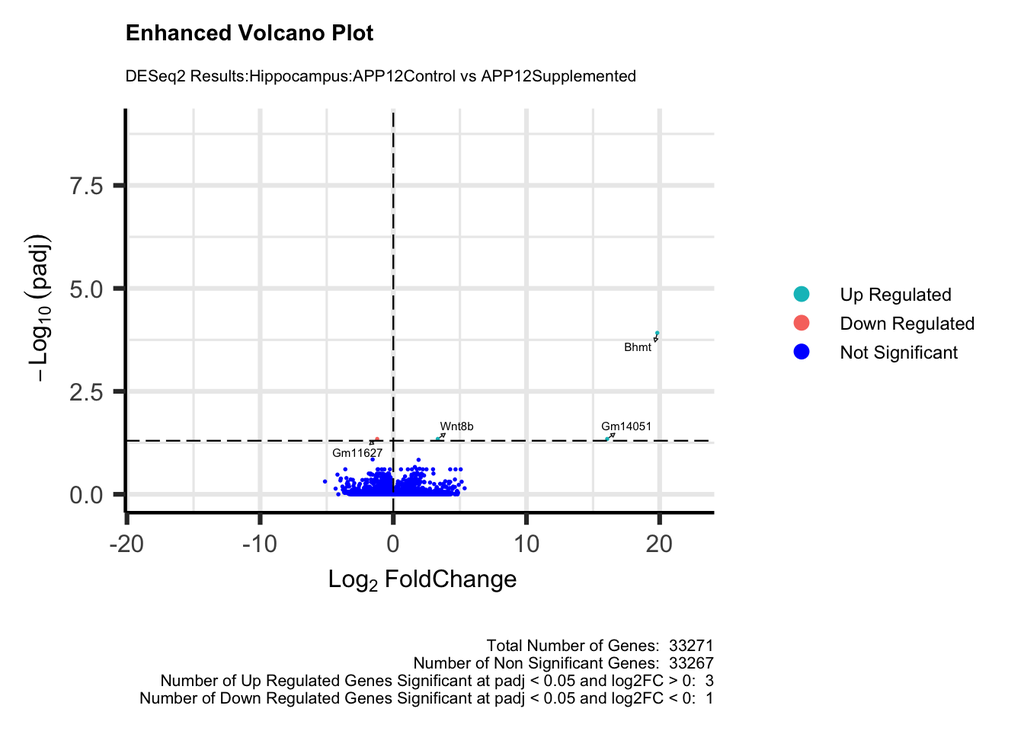

10. Hippocampus: Heatmap

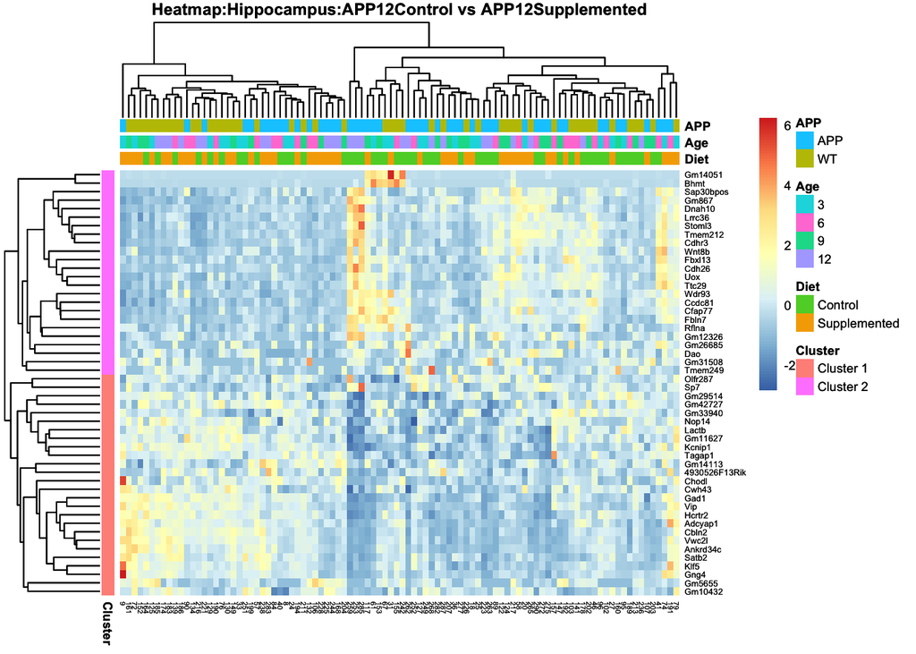

11. GSEA:Running fgsea

Perform a GSEA using a ranked list log2FoldChange values for all genes discovered in the DESeq2 results against the M2 Canonical Pathways gene set collection. Convert gene identifiers in the results to the appropriate matching format found in the M2 gene sets. fgsea expects a named vector of gene level statistics and the gene sets in the form of a named list.

Using “m2.cp.wikipathways.v0.3.symbols.gmt” which is the Canonical Pathways gene sets derived from the WikiPathways pathway database (WikiPathways subset of CP)

```
## # A tibble: 34,880 × 8
##    genes              volc_plot_…¹ log2F…²    padj baseM…³ lfcSE    stat  pvalue
##    <chr>              <chr>          <dbl>   <dbl>   <dbl> <dbl>   <dbl>   <dbl>
##  1 ENSMUSG00000075014 UP           18.9    8.58e-5   6.93  3.16   5.96   2.47e-9
##  2 ENSMUSG00000048620 NS           17.9    6.93e-2   2.42  3.88   4.61   3.98e-6
##  3 ENSMUSG00000102628 NS            0.338  1   e+0  17.9   0.470  0.720  4.71e-1
##  4 ENSMUSG00000097426 NS            0      1   e+0   0.161 8.24   0      1   e+0
##  5 ENSMUSG00000086053 NS           -0.0506 1   e+0   1.15  1.52  -0.0333 9.73e-1
##  6 ENSMUSG00000102135 NS            0.570  1   e+0   0.631 2.05   0.279  7.81e-1
##  7 ENSMUSG00000100764 NS           -0.437  1   e+0   6.12  0.556 -0.787  4.31e-1
##  8 ENSMUSG00000102095 NS            1.49   1   e+0   0.499 2.32   0.645  5.19e-1
##  9 ENSMUSG00000100635 NS            0.105  1   e+0   5.83  0.617  0.170  8.65e-1
## 10 ENSMUSG00000100480 NS            0.243  1   e+0  35.7   0.285  0.851  3.95e-1
## # … with 34,870 more rows, and abbreviated variable names ¹volc_plot_status,
## #   ²log2FoldChange, ³baseMean
## # ℹ Use `print(n = ...)` to see more rows
```

```
## # A tibble: 190 × 8
##    pathway                         pval  padj log2err     ES   NES  size leadi…¹
##    <chr>                          <dbl> <dbl>   <dbl>  <dbl> <dbl> <int> <list>
##  1 WP_PROSTAGLANDIN_SYNTHESIS_A… 0.0157     1   0.352 -0.655 -1.51    31 <chr>
##  2 WP_MIR127_IN_MESENDODERM_DIF… 0.113      1   0.181 -0.786 -1.35     7 <chr>
##  3 WP_BMP_SIGNALING_PATHWAY_IN_… 0.127      1   0.171 -0.611 -1.29    20 <chr>
##  4 WP_EICOSANOID_METABOLISM_VIA… 0.169      1   0.142 -0.541 -1.24    30 <chr>
##  5 WP_ALANINE_AND_ASPARTATE_MET… 0.186      1   0.136 -0.616 -1.24    15 <chr>
##  6 WP_OSTEOBLAST_SIGNALING       0.251      1   0.115 -0.663 -1.21     9 <chr>
##  7 WP_LEPTININSULIN_SIGNALING_O… 0.220      1   0.126 -0.591 -1.20    17 <chr>
##  8 WP_NUCLEAR_RECEPTORS_IN_LIPI… 0.209      1   0.127 -0.529 -1.20    29 <chr>
##  9 WP_SPLICING_FACTOR_NOVA_REGU… 0.196      1   0.128 -0.488 -1.19    41 <chr>
## 10 WP_BDNF_PATHWAY               0.284      1   0.107 -0.570 -1.15    15 <chr>
## # … with 180 more rows, and abbreviated variable name ¹leadingEdge
## # ℹ Use `print(n = ...)` to see more rows
```

```
## Cortex NES ordered fgsea results saved in file: 'Cortex_NES_ordered_fgsea_results_Diet_APP_12_FC0.csv'
```

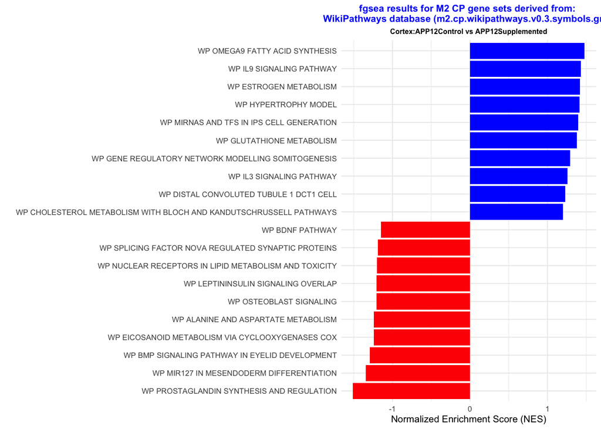

```
## # A tibble: 33,271 × 8
##    genes              volc_plot_st…¹ log2F…²    padj baseM…³ lfcSE  stat  pvalue
##    <chr>              <chr>            <dbl>   <dbl>   <dbl> <dbl> <dbl>   <dbl>
##  1 ENSMUSG00000074768 UP               19.8  1.20e-4    7.27 3.36   5.90 3.63e-9
##  2 ENSMUSG00000086756 UP               16.1  4.53e-2    5.47 3.51   4.58 4.61e-6
##  3 ENSMUSG00000078640 DOWN             -1.21 4.53e-2   75.0  0.266 -4.55 5.46e-6
##  4 ENSMUSG00000036961 UP                3.34 4.53e-2   14.0  0.729  4.58 4.73e-6
##  5 ENSMUSG00000047606 NS               -1.55 1.42e-1  221.   0.365 -4.25 2.14e-5
##  6 ENSMUSG00000054320 NS                1.90 1.46e-1   37.4  0.451  4.20 2.63e-5
##  7 ENSMUSG00000035860 NS                1.62 2.17e-1  153.   0.397  4.08 4.59e-5
##  8 ENSMUSG00000087064 NS                1.97 2.39e-1   28.8  0.489  4.02 5.77e-5
##  9 ENSMUSG00000042096 NS                2.98 2.47e-1    4.97 0.757  3.94 8.12e-5
## 10 ENSMUSG00000039099 NS                1.77 2.47e-1   23.4  0.446  3.96 7.39e-5
## # … with 33,261 more rows, and abbreviated variable names ¹volc_plot_status,
## #   ²log2FoldChange, ³baseMean
## # ℹ Use `print(n = ...)` to see more rows
```

```
## # A tibble: 190 × 8
##    pathway                         pval  padj log2err     ES   NES  size leadi…¹
##    <chr>                          <dbl> <dbl>   <dbl>  <dbl> <dbl> <int> <list>
##  1 WP_GPCRS_CLASS_B_SECRETINLIKE 0.0814     1   0.271 -0.536 -1.41    22 <chr>
##  2 WP_SEROTONIN_AND_ANXIETY      0.0916     1   0.241 -0.545 -1.39    18 <chr>
##  3 WP_TRANSCRIPTIONAL_ACTIVATIO… 0.105      1   0.222 -0.570 -1.38    14 <chr>
##  4 WP_SEROTONIN_AND_ANXIETYRELA… 0.172      1   0.168 -0.530 -1.26    13 <chr>
##  5 WP_GPCRS_PEPTIDE              0.122      1   0.253 -0.354 -1.19    69 <chr>
##  6 WP_MONOAMINE_GPCRS            0.225      1   0.161 -0.403 -1.19    33 <chr>
##  7 WP_FATTY_ACID_OMEGAOXIDATION  0.356      1   0.110 -0.613 -1.13     6 <chr>
##  8 WP_GPCRS_CLASS_A_RHODOPSINLI… 0.215      1   0.219 -0.294 -1.10   164 <chr>
##  9 WP_OSTEOCLAST_SIGNALING       0.325      1   0.119 -0.474 -1.09    12 <chr>
## 10 WP_PEROXIREDOXIN_2_INDUCED_O… 0.413      1   0.100 -0.585 -1.08     6 <chr>
## # … with 180 more rows, and abbreviated variable name ¹leadingEdge
## # ℹ Use `print(n = ...)` to see more rows
```

```
## Hippocampus NES ordered fgsea results saved in file: 'Hippocampus_NES_ordered_fgsea_results_Diet_APP_12_FC0.csv'
```

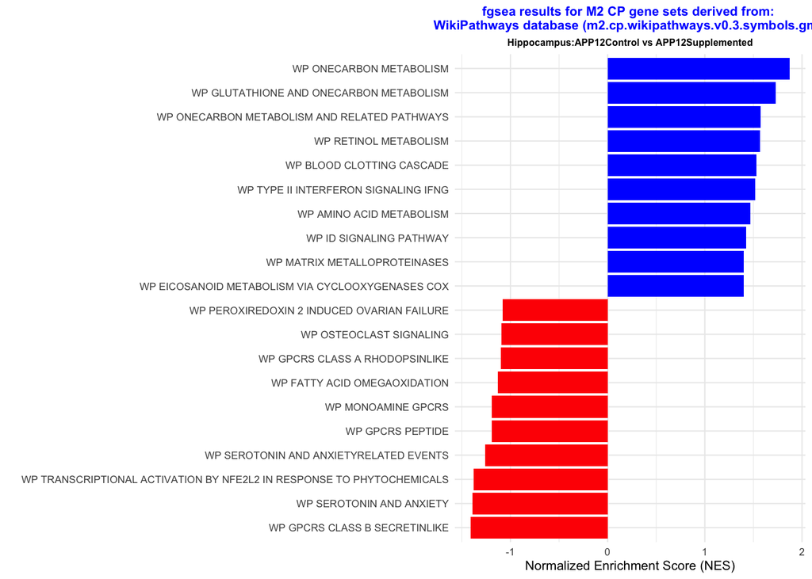